# SDHSA Milestone 4 - Final Analytical Solution

Food-insecurity risk model: preprocessing, validation, evaluation and deployment component

Person 2 - Data Science & R/Shiny (Analytical solution lead)

19 October 2026

# 1 Purpose and how to read this document

This notebook is the final, reproducible account of the **analytical solution** for the SDHSA project: it finalises the modelling pipeline, documents the preprocessing, missing-value handling, class imbalance and validation decisions, evaluates the final model on the held-out test set, and links to the R/Shiny component that deploys it. It is a refinement of Milestones 2-3, not a copy: only decisions that materially changed the final model are shown.

**Business problem (Milestone 1).** Identify households that are likely to be food insecure so that provincial and municipal planners can prioritise outreach. Success criterion: ROC AUC of at least 0.75 with at least three significant, explainable drivers. Milestone 4 adds an operating criterion that Milestone 1 lacked: recall of at least 60% at the deployed threshold.

**How the files fit together**

| File | Role |
| --- | --- |
| `preprocess.R` | Fixed cleaning rules, new-data validation, scoring (shared with the app) |
| `modelling.R` | Recipe, model specifications and evaluation helpers (this notebook and `train_model.R`) |
| `train_model.R` | Slow computations (tuning, cross-validation, refit); writes `outputs/*.csv` |
| `SDHSA_Final_Analysis.Rmd` | This notebook: reads the saved model and `outputs/`, knits in under a minute |
| `app.R`, `monitoring.R`, `run_monitoring.R` | Shiny tool and monitoring (Person 3) |
| `tests/test_deployment.R` | Automated checks of scoring, validation and the app |

```r
train_raw <- read_csv("data/train_data.csv", guess_max = Inf, show_col_types = FALSE)
test_raw  <- read_csv("data/test_data.csv",  guess_max = Inf, show_col_types = FALSE)
train <- clean_data(train_raw)
test  <- clean_data(test_raw)
saved <- readRDS("data/final_rf.rds")                       # deployed model (fitted in Milestone 3)
pred_all <- read_csv("data/test_predictions.csv", guess_max = Inf, show_col_types = FALSE)
pred_rf  <- pred_all %>% filter(model == "Random forest")
pred_lr  <- pred_all %>% filter(model == "Logistic regression")
```

# 2 Data and target

```r
tibble(
  split = c("Training", "Test (held out)"),
  households = c(nrow(train), nrow(test)),
  columns = c(ncol(train_raw), ncol(test_raw)),
  food_insecure = c(sum(train$FoodInsecure_flag == "Insecure"), sum(test$FoodInsecure_flag == "Insecure")),
  prevalence = pct(c(mean(train$FoodInsecure_flag == "Insecure"), mean(test$FoodInsecure_flag == "Insecure")))
) %>% knitr::kable(format.args = list(big.mark = ","))
```

| split | households | columns | food_insecure | prevalence |
| --- | --- | --- | --- | --- |
| Training | 16,548 | 107 | 3,043 | 18.4% |
| Test (held out) | 4,136 | 107 | 760 | 18.4% |

The analytical dataset is the household-level table built in Milestone 2 from the D01-D10 General Household Survey files (D11 cannot be joined: it comes from a different sampling frame, see Milestone 1). The target `FoodInsecure_flag` is 1 for food-insecure households. The test split was stratified, so the prevalence is the same in both splits (**18.4%** train, **18.4%** test). The test set was used once, for the final evaluation.

# 3 Preprocessing decisions

Preprocessing is split in two so that the same code runs in modelling and in the app:

- **Fixed rules** (no values learned from data) are in `preprocess.R::clean_data()`: the survey code 9 means “unknown” and becomes `NA` in 16 ordinal/yes-no columns, code 99 becomes `NA` in `ExpenditureBandCode`, and 17 nominal survey codes become factors.
- **Learned steps** (medians, modes, rare levels, correlation filter, scaling) live in a `recipe` inside the fitted workflow. They are estimated on the training data only and then applied unchanged to cross-validation folds, the test set and new households, so no information leaks from validation data.

```r
tibble(
  step = c("step_rm", "step_indicate_na", "step_impute_median / step_impute_mode", "step_novel", "step_other (1%)",
           "step_dummy", "step_zv, step_nzv", "step_corr (0.95)", "step_lincomb", "step_normalize"),
  why = c("Drop IDs, survey weights, survey year and raw duplicates of cleaned columns (34 columns)",
          "Rent is missing for households that do not rent; the missingness itself is informative",
          "Fill remaining gaps with training medians (numeric) and modes (categorical)",
          "A category not seen in training becomes 'new' instead of breaking scoring",
          "Pool levels used by under 1% of households to stabilise dummy coding",
          "One-hot style dummy variables for nominal codes",
          "Remove constant and near-constant columns",
          "Remove one of each pair of numeric predictors with |r| > 0.95 (reduces redundancy)",
          "Remove exact linear combinations (needed for logistic regression)",
          "Centre and scale (required by logistic regression; harmless for the forest)")
) %>% knitr::kable()
```

| step | why |
| --- | --- |
| step_rm | Drop IDs, survey weights, survey year and raw duplicates of cleaned columns (34 columns) |
| step_indicate_na | Rent is missing for households that do not rent; the missingness itself is informative |
| step_impute_median / step_impute_mode | Fill remaining gaps with training medians (numeric) and modes (categorical) |
| step_novel | A category not seen in training becomes ‘new’ instead of breaking scoring |
| step_other (1%) | Pool levels used by under 1% of households to stabilise dummy coding |
| step_dummy | One-hot style dummy variables for nominal codes |
| step_zv, step_nzv | Remove constant and near-constant columns |
| step_corr (0.95) | Remove one of each pair of numeric predictors with \|r\| > 0.95 (reduces redundancy) |
| step_lincomb | Remove exact linear combinations (needed for logistic regression) |
| step_normalize | Centre and scale (required by logistic regression; harmless for the forest) |

```r
n_pred <- extract_fit_engine(saved)$num.independent.variables
```

After preprocessing the model sees **82 predictors**, from 106 raw columns.

## 3.1 Missing values

```r
unk9 <- intersect(unknown9_cols, names(train_raw))
miss_tbl <- tibble(column = names(train_raw), missing_NA = colMeans(is.na(train_raw))) %>%
  filter(missing_NA > 0.02) %>% arrange(desc(missing_NA))
miss_tbl %>% mutate(missing_NA = pct(missing_NA)) %>% knitr::kable(col.names = c("Column", "Missing (NA)"))
```

| Column | Missing (NA) |
| --- | --- |
| ToiletDistanceCode_clean | 96.8% |
| DistanceToWaterCode_clean | 80.1% |
| PipedWaterCode_clean | 80.1% |
| RentRaw_clean | 75.4% |
| WaterAlternativeSourceCode_clean | 73.4% |
| WaterInterruptionFrequencyCode_clean | 55.5% |
| Income_clean_D07 | 2.1% |
| Income_per_capita | 2.1% |

Two different kinds of missingness are present, and they are treated differently:

1. **Structural (skip-logic) missingness.** `ToiletDistanceCode_clean`, `DistanceToWaterCode_clean`, `PipedWaterCode_clean`, `RentRaw_clean`, `WaterAlternativeSourceCode_clean` and `WaterInterruptionFrequencyCode_clean` are blank because the question only applies to some households (e.g. rent is asked of renters only). They are *not* random. Rent keeps an explicit missing-indicator; the other fields are median/mode-imputed, which effectively sets non-applicable households to the typical applicable value. This is the least satisfying decision in the pipeline: the model cannot “see” non-applicability for those fields, and the next improvement should be an explicit `not applicable` category (see Limitations).
2. **Genuinely unknown answers.** Code 9 / 99 are converted to `NA` and imputed, instead of being treated as a number (a 9 on a 1-2 scale would otherwise look like an extreme value).

```r
n9 <- map_int(unk9, ~ sum(train_raw[[.x]] == 9, na.rm = TRUE))
tibble(column = c(unk9, "ExpenditureBandCode (99)"),
       households = c(n9, sum(train_raw$ExpenditureBandCode == 99, na.rm = TRUE))) %>%
  filter(households > 0) %>% arrange(desc(households)) %>%
  knitr::kable(col.names = c("Column with an 'unknown' code", "Training households"),
               caption = "Households carrying the 'unknown' code in the training data.")
```

Households carrying the ‘unknown’ code in the training data.

| Column with an ‘unknown’ code | Training households |
| --- | --- |
| ComparativeIncomeCode | 3 |
| VehicleAssetCode | 3 |
| TVAssetCode | 3 |
| PayTVAssetCode | 3 |
| ComputerAssetCode | 3 |
| WashingMachineAssetCode | 3 |
| FreezerAssetCode | 3 |
| FridgeAssetCode | 3 |
| MicrowaveAssetCode | 3 |
| GeyserAssetCode | 3 |
| SolarPanelAssetCode | 3 |
| RadioAssetCode | 3 |
| ExpenditureBandCode (99) | 3 |
| RoofConditionCode | 1 |
| FloorConditionCode | 1 |
| NoIncomeCode | 1 |

Unknown codes are rare in the training data (a handful of households per column), so they have almost no effect on the fitted model. The rule matters mainly for **new uploads**, where raw survey extracts can contain more of them. Code 9 is *not* converted for `ExpenditureBandCode`, where 9 is a genuine income band (3,085 households); only its code 99 means unknown.

## 3.2 A naming problem found while validating the inputs

```r
tibble(column = c("SalaryEarnersInHousehold", "TotalGrantRecipients"),
       share_above_20 = c(mean(train_raw$SalaryEarnersInHousehold > 20), mean(train_raw$TotalGrantRecipients > 20)),
       maximum = c(max(train_raw$SalaryEarnersInHousehold), max(train_raw$TotalGrantRecipients))) %>%
  mutate(share_above_20 = pct(share_above_20)) %>% knitr::kable(format.args = list(big.mark = ","))
```

| column | share_above_20 | maximum |
| --- | --- | --- |
| SalaryEarnersInHousehold | 63.5% | 9,999,999 |
| TotalGrantRecipients | 58.6% | 12,980 |

```r
share_sum <- mean(train_raw$SalaryEarnersInHousehold + train_raw$TotalGrantRecipients == train_raw$Income_clean_D07, na.rm = TRUE)
```

In **83%** of households, salary column + grant column equals household income exactly. These columns therefore hold **Rand amounts (salary income and grant income), not counts of people**, despite their names. The model is unaffected (it only sees numbers), but the report and the app must describe them as *salary income* and *grant income*, and the drift check treats them as continuous. We recommend renaming them in the Milestone 2 dataset and data dictionary. Because they sum to household income, they are close to a decomposition of the same quantity as `Income_clean_D07`, which partly explains why several income-type variables share the top of the importance ranking.

# 4 Class imbalance

```r
base <- mean(train$FoodInsecure_flag == "Insecure")
```

Only **18.4%** of households are food insecure. A model that predicts “secure” for every household would be **81.6% accurate** and find none of the households we care about, so *accuracy is not used*. Instead the pipeline uses:

- **Stratified** splitting and cross-validation, so every fold has the same prevalence;
- **Threshold-free** measures for model selection (ROC AUC, precision-recall AUC, Brier score) and **recall / precision at a chosen threshold** for the operating decision;
- **Moving the decision threshold** from 0.50 to 0.30 instead of re-balancing the training data. With the default 0.50 cut-off the forest finds only 25% of food-insecure households.

To check that this choice is not hiding a better option, three ways of handling imbalance were compared in the same 5-fold cross-validation (`train_model.R`). Class weights give each food-insecure household 4.4 times the weight of a secure one; down-sampling trims the majority class to equal size inside each training fold (never in the validation fold).

```r
need("outputs/cv_model_comparison.csv")
cv <- read_csv("outputs/cv_model_comparison.csv", show_col_types = FALSE)
cv %>% transmute(Model = model,
                 `ROC AUC` = sprintf("%.3f (%.3f)", roc_auc_mean, roc_auc_sd),
                 `PR AUC` = sprintf("%.3f (%.3f)", pr_auc_mean, pr_auc_sd),
                 `Brier score` = sprintf("%.3f (%.3f)", brier_mean, brier_sd),
                 `Recall, top 24% flagged` = sprintf("%.3f (%.3f)", recall_top24_mean, recall_top24_sd)) %>%
  knitr::kable(caption = "Cross-validated results on the training data, mean (SD across folds). Brier: lower is better.")
```

Cross-validated results on the training data, mean (SD across folds). Brier: lower is better.

| Model | ROC AUC | PR AUC | Brier score | Recall, top 24% flagged |
| --- | --- | --- | --- | --- |
| Logistic regression | 0.819 (0.007) | 0.517 (0.008) | 0.117 (0.001) | 0.602 (0.009) |
| Random forest (final spec) | 0.830 (0.004) | 0.556 (0.009) | 0.114 (0.000) | 0.624 (0.008) |
| RF + class weights | 0.829 (0.004) | 0.556 (0.009) | 0.114 (0.000) | 0.625 (0.008) |
| RF + down-sampling | 0.825 (0.005) | 0.534 (0.012) | 0.175 (0.003) | 0.610 (0.011) |

```r
rf <- cv %>% filter(model == "Random forest (final spec)"); cw <- cv %>% filter(model == "RF + class weights")
ds <- cv %>% filter(grepl("down", model))
cat(sprintf(
  "Class weights change almost nothing (ROC AUC %.3f vs %.3f, Brier score %.3f vs %.3f): the final forest grows deep trees (`min_n = 2`), whose leaves are nearly pure, so there is little left for the weights to act on. Down-sampling is worse on every measure (ROC AUC %.3f, PR AUC %.3f vs %.3f) and badly distorts the probabilities (Brier score %.3f vs %.3f), because the model is trained on a 50/50 world and then asked to score an 18/82 one. The app reports probabilities as risk scores, so **the plain forest plus a lower decision threshold is retained**.\n",
  cw$roc_auc_mean, rf$roc_auc_mean, cw$brier_mean, rf$brier_mean,
  ds$roc_auc_mean, ds$pr_auc_mean, rf$pr_auc_mean, ds$brier_mean, rf$brier_mean))
```

Class weights change almost nothing (ROC AUC 0.829 vs 0.830, Brier score 0.114 vs 0.114): the final forest grows deep trees (`min_n = 2`), whose leaves are nearly pure, so there is little left for the weights to act on. Down-sampling is worse on every measure (ROC AUC 0.825, PR AUC 0.534 vs 0.556) and badly distorts the probabilities (Brier score 0.175 vs 0.114), because the model is trained on a 50/50 world and then asked to score an 18/82 one. The app reports probabilities as risk scores, so **the plain forest plus a lower decision threshold is retained**.

# 5 Validation strategy

| Level | Method | Purpose |
| --- | --- | --- |
| Hold-out | 80/20 stratified split made in Milestone 2 (16,548 / 4,136); test set touched once | Unbiased final estimate |
| Cross-validation | 5-fold stratified on the training set, `set.seed(381)` | Tuning and model comparison |
| Leakage control | All learned preprocessing is inside the workflow and refitted per fold | Validation folds never influence imputation, scaling or filters |
| Uncertainty | Bootstrap (1,000 resamples) 95% intervals on the test set | Shows how much a single test number can move |

Note for the team: if Milestone 3 used a different number of folds, change `FOLDS` in `train_model.R` (`Rscript train_model.R 10`) and re-knit.

# 6 Model selection and tuning

```r
need("outputs/tuning_results.csv")
tune_res <- read_csv("outputs/tuning_results.csv", show_col_types = FALSE)
tune_res %>% transmute(mtry, min_n,
                       `ROC AUC` = round(mean_roc_auc, 4), `PR AUC` = round(mean_pr_auc, 4),
                       `Brier` = round(mean_brier_class, 4), `AUC std. error` = round(std_err_roc_auc, 4)) %>%
  head(8) %>% knitr::kable(caption = "Top 8 of 15 random-forest settings (500 trees, 5-fold CV), ranked by ROC AUC.")
```

Top 8 of 15 random-forest settings (500 trees, 5-fold CV), ranked by ROC AUC.

| mtry | min_n | ROC AUC | PR AUC | Brier | AUC std. error |
| --- | --- | --- | --- | --- | --- |
| 11 | 2 | 0.8295 | 0.5564 | 0.1137 | 0.0018 |
| 5 | 2 | 0.8293 | 0.5579 | 0.1144 | 0.0019 |
| 20 | 2 | 0.8289 | 0.5561 | 0.1135 | 0.0019 |
| 15 | 2 | 0.8288 | 0.5572 | 0.1135 | 0.0014 |
| 8 | 2 | 0.8284 | 0.5563 | 0.1140 | 0.0021 |
| 11 | 10 | 0.8284 | 0.5556 | 0.1140 | 0.0021 |
| 15 | 10 | 0.8282 | 0.5545 | 0.1139 | 0.0014 |
| 20 | 10 | 0.8281 | 0.5531 | 0.1139 | 0.0013 |

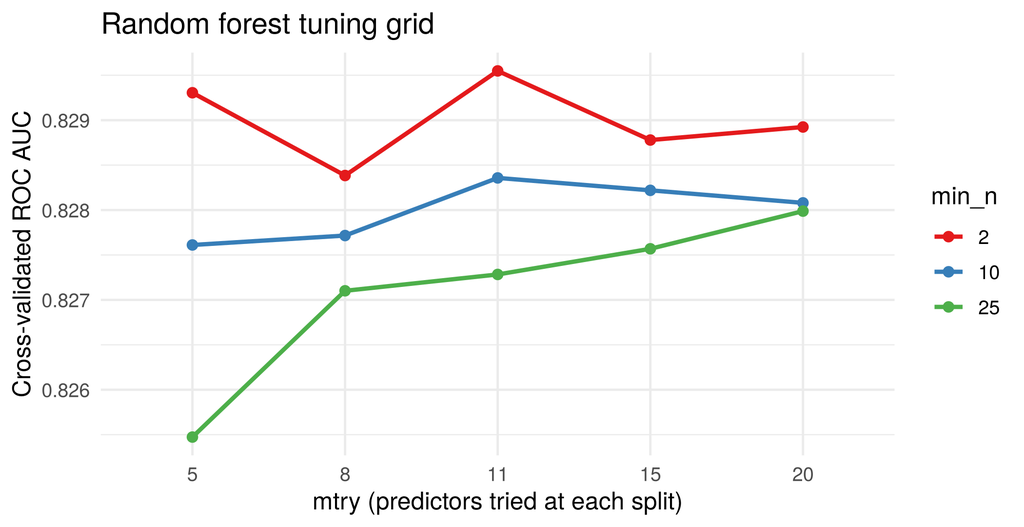

```r
ggplot(tune_res, aes(factor(mtry), mean_roc_auc, colour = factor(min_n), group = min_n)) +
  geom_line(linewidth = 1) + geom_point(size = 2) +
  scale_colour_brewer(palette = "Set1") +
  labs(x = "mtry (predictors tried at each split)", y = "Cross-validated ROC AUC", colour = "min_n",
       title = "Random forest tuning grid")
```

```r
best <- tune_res[1, ]; chosen <- tune_res %>% filter(mtry == 11, min_n == 2)
n_close <- sum(tune_res$mean_roc_auc >= best$mean_roc_auc - 0.002)
cat(sprintf("The best cross-validated setting is **mtry = %d, min_n = %d** (AUC %.4f), which %s the setting used by the deployed model (mtry = 11, min_n = 2). %d of the 15 settings are within 0.002 AUC of the best, against a fold-to-fold standard error of about %.3f, so the surface is flat: the choice of tuning values matters far less than the choice of predictors. `min_n = 25` is slightly worse than 2 or 10 for every `mtry`, but the gap is small.\n",
            best$mtry, best$min_n, best$mean_roc_auc, if (best$mtry == 11 && best$min_n == 2) "is the same as" else "is close to", n_close, best$std_err_roc_auc))
```

The best cross-validated setting is **mtry = 11, min_n = 2** (AUC 0.8295), which is the same as the setting used by the deployed model (mtry = 11, min_n = 2). 12 of the 15 settings are within 0.002 AUC of the best, against a fold-to-fold standard error of about 0.002, so the surface is flat: the choice of tuning values matters far less than the choice of predictors. `min_n = 25` is slightly worse than 2 or 10 for every `mtry`, but the gap is small.

**Random forest versus logistic regression.** Logistic regression is the transparent benchmark. The forest was chosen because it ranks better, handles interactions and non-linear income effects without manual terms, and needs no distributional assumptions; the cost is that it is less directly interpretable (addressed through variable importance below and the model card in the app).

```r
cv %>% filter(model %in% c("Logistic regression", "Random forest (final spec)")) %>%
  transmute(Model = model, `ROC AUC (CV)` = sprintf("%.3f", roc_auc_mean),
            `PR AUC (CV)` = sprintf("%.3f", pr_auc_mean), `Brier (CV)` = sprintf("%.3f", brier_mean)) %>%
  knitr::kable()
```

| Model | ROC AUC (CV) | PR AUC (CV) | Brier (CV) |
| --- | --- | --- | --- |
| Logistic regression | 0.819 | 0.517 | 0.117 |
| Random forest (final spec) | 0.830 | 0.556 | 0.114 |

# 7 Final model: evaluation on the held-out test set

```r
# 1. The deployed model reproduces the saved test predictions exactly
scored  <- score_households(test_raw, saved, threshold = 0.30)$scores
max_diff <- max(abs(scored$prob_insecure - pred_rf$.pred_Insecure))
truth <- factor(pred_rf$FoodInsecure_flag, levels = c("Insecure", "Secure"))
p_rf  <- pred_rf$.pred_Insecure
p_lr  <- pred_lr$.pred_Insecure
```

Scoring the test set with the deployed workflow through `score_households()` (the function the app uses) reproduces the saved predictions to within **1.1e-16**, so the numbers below are exactly what the app produces.

## 7.1 Ranking quality

```r
m <- bind_rows(
  overall_metrics(truth, p_rf) %>% mutate(model = "Random forest"),
  overall_metrics(truth, p_lr) %>% mutate(model = "Logistic regression")) %>%
  select(model, everything())
ci <- bootstrap_ci(truth, p_rf, threshold = 0.30)
m %>% transmute(Model = model, `ROC AUC` = round(roc_auc, 3), `PR AUC` = round(pr_auc, 3),
                `Brier score` = round(brier, 3), `Recall, top 24% flagged` = round(recall_top24, 3)) %>%
  knitr::kable(caption = "Test-set results (4,136 households).")
```

Test-set results (4,136 households).

| Model | ROC AUC | PR AUC | Brier score | Recall, top 24% flagged |
| --- | --- | --- | --- | --- |
| Random forest | 0.840 | 0.539 | 0.113 | 0.636 |
| Logistic regression | 0.819 | 0.496 | 0.118 | 0.612 |

The random forest’s ROC AUC is **0.840** (95% bootstrap interval 0.825-0.855), above the Milestone 1 target of 0.75 and above logistic regression (0.819). The precision-recall AUC (0.539) is the more demanding summary under imbalance: a random model would score about the base rate of 0.184.

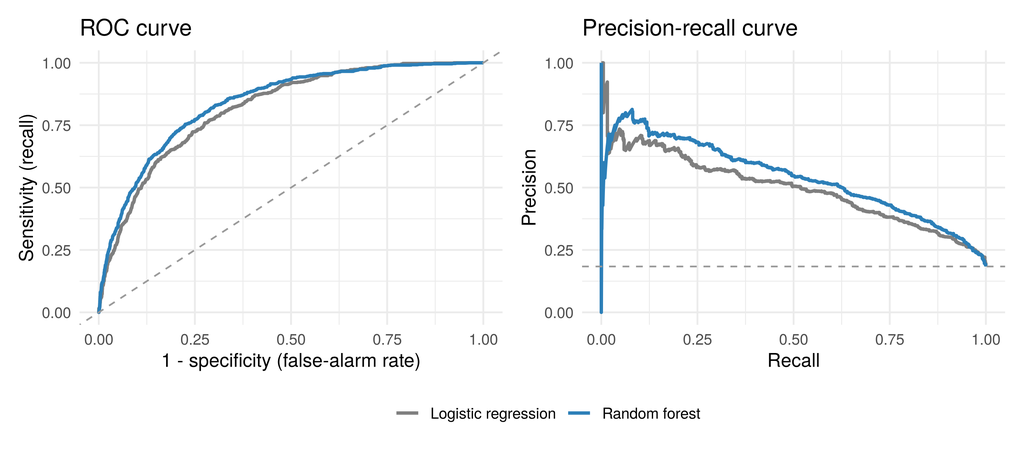

```r
curves <- bind_rows(
  tibble(model = "Random forest", truth = truth, p = p_rf),
  tibble(model = "Logistic regression", truth = truth, p = p_lr))
roc <- curves %>% group_by(model) %>% roc_curve(truth, p, event_level = "first")
pr  <- curves %>% group_by(model) %>% pr_curve(truth, p, event_level = "first")
cols <- c("Random forest" = col_rf, "Logistic regression" = col_lr)
g1 <- ggplot(roc, aes(1 - specificity, sensitivity, colour = model)) + geom_line(linewidth = 1) +
  geom_abline(linetype = "dashed", colour = "grey60") + scale_colour_manual(values = cols) +
  labs(title = "ROC curve", x = "1 - specificity (false-alarm rate)", y = "Sensitivity (recall)", colour = NULL)
g2 <- ggplot(pr, aes(recall, precision, colour = model)) + geom_line(linewidth = 1) +
  geom_hline(yintercept = mean(truth == "Insecure"), linetype = "dashed", colour = "grey60") +
  scale_colour_manual(values = cols) + coord_cartesian(ylim = c(0, 1)) +
  labs(title = "Precision-recall curve", x = "Recall", y = "Precision", colour = NULL)
library(patchwork); (g1 + g2) + plot_layout(guides = "collect") & theme(legend.position = "bottom")
```

## 7.2 Threshold choice and confusion matrices

```r
tt <- threshold_table(truth, p_rf)
tt %>% filter(threshold %in% c(0.2, 0.3, 0.4, 0.5)) %>%
  transmute(Threshold = threshold, TP = tp, FP = fp, FN = fn, TN = tn,
            Recall = round(recall, 3), Precision = round(precision, 3), Specificity = round(specificity, 3),
            F1 = round(f1, 3), `Share flagged` = round(flagged_share, 3)) %>% knitr::kable(
  caption = "Random forest on the test set. A household is flagged when its probability is >= the threshold (the rule used by the app).")
```

Random forest on the test set. A household is flagged when its probability is >= the threshold (the rule used by the app).

| Threshold | TP | FP | FN | TN | Recall | Precision | Specificity | F1 | Share flagged |
| --- | --- | --- | --- | --- | --- | --- | --- | --- | --- |
| 0.2 | 625 | 1010 | 135 | 2366 | 0.822 | 0.382 | 0.701 | 0.522 | 0.395 |
| 0.3 | 482 | 506 | 278 | 2870 | 0.634 | 0.488 | 0.850 | 0.551 | 0.239 |
| 0.4 | 330 | 237 | 430 | 3139 | 0.434 | 0.582 | 0.930 | 0.497 | 0.137 |
| 0.5 | 187 | 88 | 573 | 3288 | 0.246 | 0.680 | 0.974 | 0.361 | 0.066 |

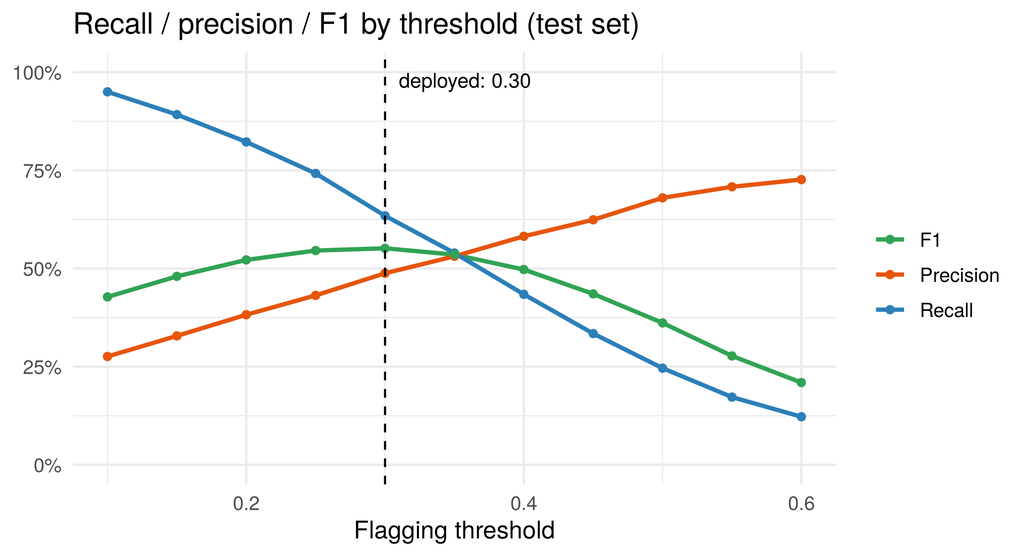

```r
tt %>% select(threshold, Recall = recall, Precision = precision, F1 = f1) %>%
  pivot_longer(-threshold) %>%
  ggplot(aes(threshold, value, colour = name)) + geom_line(linewidth = 1) + geom_point() +
  geom_vline(xintercept = DEPLOY_THRESHOLD, linetype = "dashed") +
  annotate("text", x = DEPLOY_THRESHOLD + 0.01, y = 0.98, label = "deployed: 0.30", hjust = 0, size = 3.5) +
  scale_y_continuous(labels = percent, limits = c(0, 1)) +
  scale_colour_manual(values = c(Recall = col_rf, Precision = "#e6550d", F1 = "#31a354")) +
  labs(x = "Flagging threshold", y = NULL, colour = NULL, title = "Recall / precision / F1 by threshold (test set)")
```

```r
a <- tt %>% filter(abs(threshold - 0.5) < 1e-9); b <- tt %>% filter(abs(threshold - 0.3) < 1e-9)
cat(sprintf("At the default **0.50** the forest finds only %s of food-insecure households (%d of %d) although %s of its flags are right. At **0.30** it finds %s (%d of %d) with %s precision, and F1 is at its maximum (%.2f) across the grid. The price is %d false alarms: about one flag in two is a household that is not food insecure, and %s of all households are flagged against an %s base rate. This is acceptable for *screening and prioritisation with human review*, and is not acceptable for individual eligibility decisions. The threshold is a business choice (cost of a missed household versus a false alarm) and should be confirmed by the programme owner.\n",
  pct(a$recall, 0), a$tp, a$tp + a$fn, pct(a$precision, 0), pct(b$recall, 0), b$tp, b$tp + b$fn, pct(b$precision, 0), max(tt$f1), b$fp, pct(b$flagged_share, 0), pct(mean(truth == "Insecure"), 0)))
```

At the default **0.50** the forest finds only 25% of food-insecure households (187 of 760) although 68% of its flags are right. At **0.30** it finds 63% (482 of 760) with 49% precision, and F1 is at its maximum (0.55) across the grid. The price is 506 false alarms: about one flag in two is a household that is not food insecure, and 24% of all households are flagged against an 18% base rate. This is acceptable for *screening and prioritisation with human review*, and is not acceptable for individual eligibility decisions. The threshold is a business choice (cost of a missed household versus a false alarm) and should be confirmed by the programme owner.

## 7.3 Are the probabilities usable as risk scores?

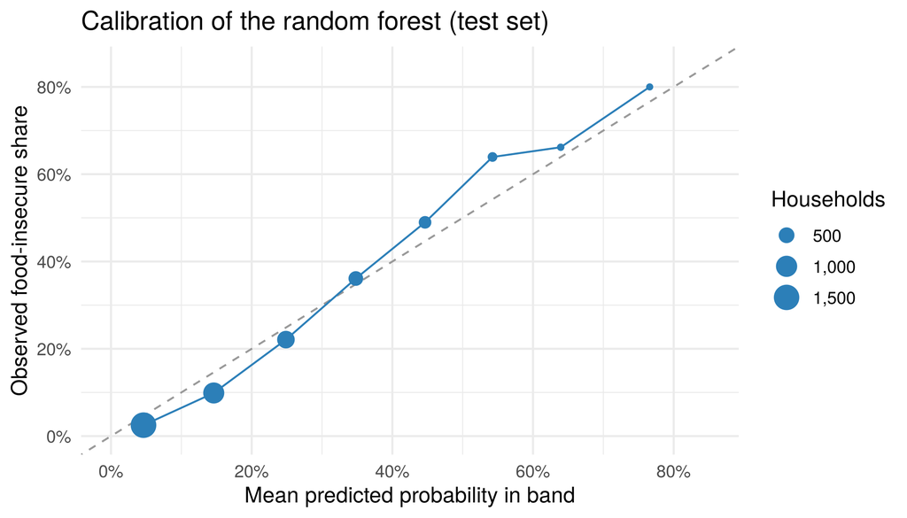

```r
cal <- calibration_table(truth, p_rf)
ggplot(cal, aes(mean_predicted, observed_rate)) +
  geom_abline(linetype = "dashed", colour = "grey60") +
  geom_line(colour = col_rf) + geom_point(aes(size = households), colour = col_rf) +
  scale_x_continuous(labels = percent, limits = c(0, 0.85)) + scale_y_continuous(labels = percent, limits = c(0, 0.85)) +
  scale_size_area(max_size = 6, labels = comma) +
  labs(x = "Mean predicted probability in band", y = "Observed food-insecure share", size = "Households",
       title = "Calibration of the random forest (test set)")
```

```r
cal %>% mutate(across(c(mean_predicted, observed_rate), ~ pct(.x))) %>%
  knitr::kable(col.names = c("Probability band", "Households", "Mean predicted", "Observed"))
```

| Probability band | Households | Mean predicted | Observed |
| --- | --- | --- | --- |
| [0,0.1) | 1519 | 4.6% | 2.5% |
| [0.1,0.2) | 982 | 14.6% | 9.9% |
| [0.2,0.3) | 647 | 24.9% | 22.1% |
| [0.3,0.4) | 421 | 34.8% | 36.1% |
| [0.4,0.5) | 292 | 44.6% | 49.0% |
| [0.5,0.6) | 147 | 54.2% | 63.9% |
| [0.6,0.7) | 68 | 63.9% | 66.2% |
| [0.7,1) | 60 | 76.6% | 80.0% |

The points sit close to the diagonal from 0.2 upward. The forest slightly **over-estimates** risk in low-probability bands (4.6% predicted vs 2.5% observed below 0.10) and slightly **under-estimates** it between 0.5 and 0.6 (54% predicted vs 64% observed). This is a common pattern for random forests; it means the probabilities are good for ranking and banding, and should be read as approximate rather than exact percentages (the app shows a risk band and a base-rate reminder for this reason).

## 7.4 Fairness and subgroup checks

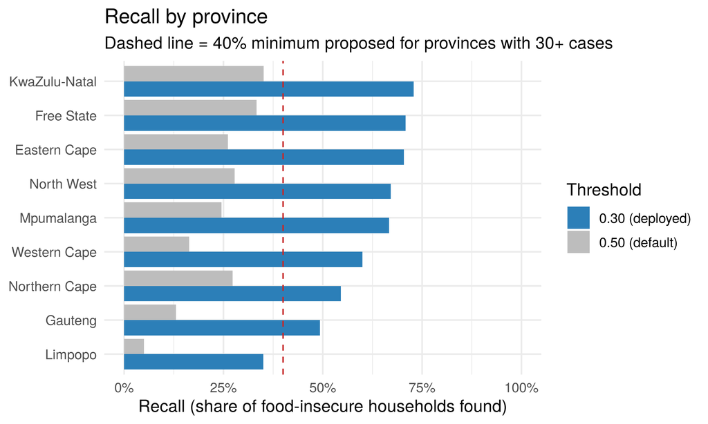

```r
prov_df <- test %>% mutate(province = unname(PROVINCES[as.character(ProvinceCode)]))
prov_tab <- bind_rows(
  subgroup_recall(prov_df, truth, p_rf, "province", 0.30) %>% mutate(threshold = "0.30 (deployed)"),
  subgroup_recall(prov_df, truth, p_rf, "province", 0.50) %>% mutate(threshold = "0.50 (default)"))
prov_order <- prov_tab %>% filter(threshold == "0.30 (deployed)") %>% arrange(recall) %>% pull(province)
ggplot(prov_tab, aes(recall, factor(province, levels = prov_order), fill = threshold)) +
  geom_col(position = "dodge") +
  geom_vline(xintercept = 0.40, linetype = "dashed", colour = col_bad) +
  scale_x_continuous(labels = percent, limits = c(0, 1)) +
  scale_fill_manual(values = c("0.30 (deployed)" = col_rf, "0.50 (default)" = "#bdbdbd")) +
  labs(x = "Recall (share of food-insecure households found)", y = NULL, fill = "Threshold",
       title = "Recall by province", subtitle = "Dashed line = 40% minimum proposed for provinces with 30+ cases")
```

```r
prov_tab %>% filter(threshold == "0.30 (deployed)") %>%
  mutate(rate = pct(insecure / households), recall = pct(recall, 0)) %>%
  select(Province = province, Households = households, `Food insecure` = insecure, `Base rate` = rate, Recall = recall, Note = note) %>%
  arrange(desc(Households)) %>% knitr::kable()
```

| Province | Households | Food insecure | Base rate | Recall | Note |
| --- | --- | --- | --- | --- | --- |
| Gauteng | 1116 | 146 | 13.1% | 49% |  |
| KwaZulu-Natal | 676 | 151 | 22.3% | 73% |  |
| Eastern Cape | 511 | 115 | 22.5% | 70% |  |
| Limpopo | 462 | 20 | 4.3% | 35% | too few cases |
| Western Cape | 367 | 55 | 15.0% | 60% |  |
| Mpumalanga | 341 | 102 | 29.9% | 67% |  |
| North West | 275 | 79 | 28.7% | 67% |  |
| Free State | 216 | 48 | 22.2% | 71% |  |
| Northern Cape | 172 | 44 | 25.6% | 55% |  |

```r
grp <- bind_rows(
  subgroup_recall(test, truth, p_rf, "HeadSexCode") %>% mutate(group = "Head of household sex code", level = as.character(HeadSexCode)),
  subgroup_recall(test, truth, p_rf, "GeoTypeCode") %>% mutate(group = "Geography type code", level = as.character(GeoTypeCode)),
  subgroup_recall(test, truth, p_rf, "HeadPopulationGroupCode") %>% mutate(group = "Population group code", level = as.character(HeadPopulationGroupCode)))
grp %>% transmute(Group = group, Code = level, Households = households, `Food insecure` = insecure,
                  Recall = pct(recall, 0), Note = note) %>% knitr::kable()
```

| Group | Code | Households | Food insecure | Recall | Note |
| --- | --- | --- | --- | --- | --- |
| Head of household sex code | 1 | 2336 | 404 | 60% |  |
| Head of household sex code | 2 | 1800 | 356 | 67% |  |
| Geography type code | 1 | 2674 | 424 | 59% |  |
| Geography type code | 2 | 1312 | 314 | 70% |  |
| Geography type code | 3 | 150 | 22 | 64% | too few cases |
| Population group code | 1 | 3495 | 701 | 64% |  |
| Population group code | 2 | 282 | 54 | 61% |  |
| Population group code | 3 | 78 | 1 | 100% | too few cases |
| Population group code | 4 | 281 | 4 | 0% | too few cases |

# 8 What drives the predictions?

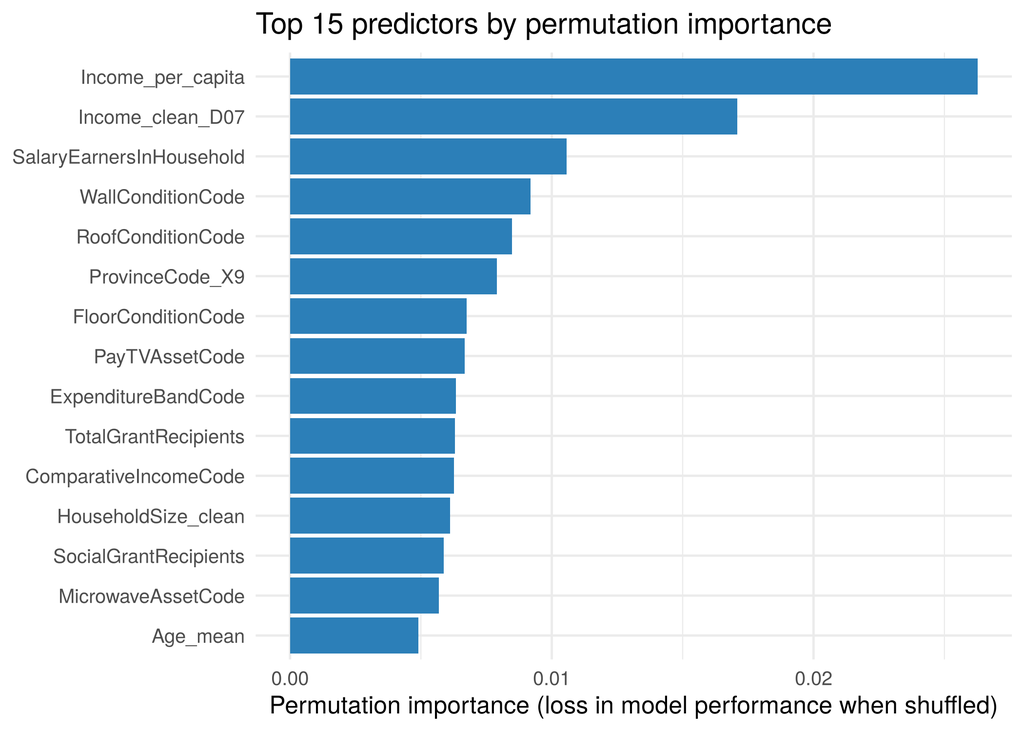

```r
need("outputs/permutation_importance.csv")
imp_gini <- tibble(feature = names(ranger::importance(extract_fit_engine(saved))),
                   impurity = unname(ranger::importance(extract_fit_engine(saved))))
imp_perm <- read_csv("outputs/permutation_importance.csv", show_col_types = FALSE)
top <- imp_perm %>% slice_max(permutation, n = 15) %>% arrange(permutation)
ggplot(top, aes(permutation, factor(feature, levels = feature))) + geom_col(fill = col_rf) +
  labs(x = "Permutation importance (loss in model performance when shuffled)", y = NULL,
       title = "Top 15 predictors by permutation importance")
```

```r
imp_gini %>% slice_max(impurity, n = 10) %>% mutate(impurity = round(impurity, 1)) %>%
  left_join(imp_perm %>% mutate(perm_rank = row_number()), by = "feature") %>%
  transmute(`Top 10 by impurity` = feature, Impurity = impurity, `Permutation rank` = perm_rank) %>% knitr::kable()
```

| Top 10 by impurity | Impurity | Permutation rank |
| --- | --- | --- |
| Income_per_capita | 391.6 | 1 |
| Income_clean_D07 | 282.2 | 2 |
| Age_mean | 229.9 | 15 |
| HeadAge | 216.4 | 17 |
| ComparativeIncomeCode | 187.1 | 11 |
| SalaryEarnersInHousehold | 168.3 | 3 |
| ExpenditureBandCode | 159.1 | 9 |
| TotalGrantRecipients | 139.7 | 10 |
| TotalRooms_clean | 135.9 | 20 |
| RoofConditionCode | 123.7 | 5 |

The two importance measures agree on the top of the ranking but disagree lower down, and the disagreement is informative. Impurity importance favours continuous variables with many possible split points, so head age and mean household age rank 3rd-4th by impurity but only 15th and 17th by permutation. The permutation ranking (the safer one to quote) puts **income** first (income per capita, household income, salary income), followed by **dwelling quality** (wall, roof and floor condition), **province** (the Limpopo indicator, `ProvinceCode_X9`, reflects its very low base rate), **household assets** (pay-TV), **expenditure band**, **perceived income** (comparative income rating), **grant income** and **household size**. This matches the Milestone 1 hypotheses and the logistic regression drivers.

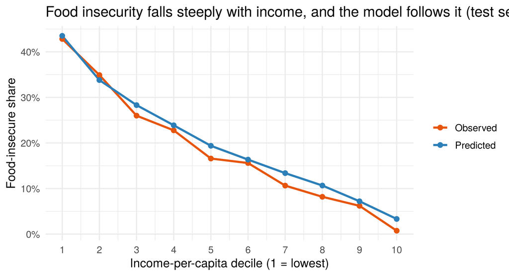

```r
dec <- tibble(income = test$Income_per_capita, y = truth == "Insecure", p = p_rf) %>%
  filter(!is.na(income)) %>% mutate(decile = ntile(income, 10)) %>%
  group_by(decile) %>% summarise(Observed = mean(y), Predicted = mean(p), .groups = "drop") %>%
  pivot_longer(-decile)
ggplot(dec, aes(decile, value, colour = name)) + geom_line(linewidth = 1) + geom_point(size = 2) +
  scale_x_continuous(breaks = 1:10) + scale_y_continuous(labels = percent) +
  scale_colour_manual(values = c(Observed = "#e6550d", Predicted = col_rf)) +
  labs(x = "Income-per-capita decile (1 = lowest)", y = "Food-insecure share", colour = NULL,
       title = "Food insecurity falls steeply with income, and the model follows it (test set)")
```

**Interpretation caution.** These are associations in one year of survey data. The importance ranking says which inputs the model relies on, not that changing them would change a household’s food security. The two largest income variables are strongly related to each other and to the salary/grant columns, so the importance between them should not be split finely.

# 9 Deployed R/Shiny component

The Shiny app (`app.R`) wraps the saved workflow with four tabs: batch scoring, a what-if household, monitoring (PSI drift, data quality, performance and province fairness) and a model card. Changes made in Milestone 4 to make it reliable:

- Removed a hard-coded `setwd("C:\\Users\\...")` and an automatic `install_packages.R` call at start-up. The first is a syntax error in R (`\U` is not a valid escape) and would stop the app on every machine; the app now runs from the project folder with `shiny::runApp()`.
- `preprocess.R` loads only the packages it needs (`recipes`, `parsnip`, `workflows`, `tidyverse`) instead of the whole `tidymodels` bundle.
- Added **range checks** to `validate_new_data()` (e.g. head age 10-120, household size 1-40, non-negative income): implausible values become missing, are imputed by the recipe and are reported to the user. This closes the gap listed in the Milestone 3 report.
- Skip-logic fields that are always largely empty no longer trigger a “predictions are less reliable” warning on valid data.
- Clear message if the user unticks the demo data but has not uploaded a file.

````r
res <- tryCatch(system2("Rscript", "tests/test_deployment.R", stdout = TRUE, stderr = TRUE), error = function(e) paste("could not run:", conditionMessage(e)))
cat("```\n", paste(res[grepl("PASS|FAIL|passed", res)], collapse = "\n"), "\n```\n")
````

```
 [PASS] scores 4,136 households
[PASS] probabilities match saved predictions (max diff < 1e-9)
[PASS] probabilities are within [0, 1]
[PASS] AUC 0.840
[PASS] recall 0.634
[PASS] precision 0.488
[PASS] unlabelled file with an extra column scores
[PASS] missing essential column stops with a clear message
[PASS] implausible age is reported and does not break scoring
[PASS] unseen category is handled
[PASS] text in a numeric column is converted and reported
[PASS] Shiny app: all 13 outputs render; threshold slider updates flags
All deployment checks passed.
```

# 10 Findings, limitations and future improvements

**Findings**

1. The tuned random forest ranks households well (ROC AUC 0.840, 95% CI 0.825-0.855) and beats logistic regression (0.819), meeting the 0.75 Milestone 1 criterion. Re-balancing did not help: class weights made no difference and down-sampling made both ranking and calibration worse.
2. With the default threshold it misses three in four food-insecure households. At **0.30** it finds 63% with 49% precision, meeting the proposed 60% recall criterion.
3. Income, dwelling quality, province, household assets and spending are the main drivers, consistent with the Milestone 1 hypotheses; age matters less than impurity importance suggests.
4. Performance is uneven by province (35-73% recall); Limpopo and Gauteng need extra care.

**Limitations and assumptions**

- One survey year (2024) and one hold-out split: performance on a future year is unknown, and the test-set figures carry sampling uncertainty (shown as intervals).
- Survey weights were dropped from the model, so results describe sampled households, not weighted population totals.
- Structurally missing fields are imputed rather than modelled as “not applicable” (see Missing values).
- `SalaryEarnersInHousehold` and `TotalGrantRecipients` contain Rand amounts despite their names; income-type predictors are strongly related to one another.
- Probabilities are slightly too high at the bottom and too low around 0.5-0.6; use bands, not exact percentages.
- The what-if tab holds all unlisted fields at typical values, including the salary and grant income columns, so changing “household income” there does not change those two fields. It illustrates the model only.
- Associations only: nothing here is causal, and the tool must not be used for automated eligibility decisions.

**Future improvements (in order of expected value)**

1. Add explicit “not applicable” categories for skip-logic fields and test their effect on recall.
2. Test **province-specific thresholds** or a province-aware calibration, and collect more data for small provinces and population groups.
3. Compare a regularised logistic model and a gradient-boosted model, and calibrate probabilities (Platt or isotonic) on a validation split.
4. Use survey weights (as case weights) to check whether conclusions hold for the population.
5. Re-validate every survey cycle, as set out in the monitoring plan, and commit an `renv.lock` so package versions match the saved model.